# Air Quality Index ETL

Katie Masiello

12/2/2020

Build the API query URL

```r
base_url <- "https://www.airnowapi.org/aq/data/"

# variable endpoints
# Query the API for current date and the last `timespan` hours
timespan <- 24 #hours
.now <- now("UTC")
.then <- .now - hours(timespan)

endDate <- paste0("endDate=",date(.now),"T",stringr::str_pad(hour(.now),width = 2,pad = 0))
startDate <- paste0("startDate=",date(.then),"T",stringr::str_pad(hour(.then),width = 2,pad = 0))

# constant endpoints
parameters <- "parameters=OZONE,PM25,PM10,CO,NO2,SO2"
boundingBox <- "BBOX=-123.146648,46.996876,-121.487713,48.204308"
dataType <- "dataType=B"
format <- "format=text/csv"
verbose <- "verbose=1"
nowcastonly <- "nowcastonly=1"
includeRaw <- "includerawconcentrations=1"
# API_KEY <- paste0("API_KEY=",Sys.getenv("AIRNOW_API_KEY"))

url_sansKey <- paste(paste0(base_url,"?",
                    startDate),
             endDate,
             parameters,
             boundingBox,
             dataType,
             format,
             verbose,
             nowcastonly,
             includeRaw,sep="&")
```

# Query the API

```r
# column names
cols <- c("Latitude", "Longitude", "UTC", "Pollutant",
          "Concentration", "Unit", "Raw_Concentration",
          "AQI", "Category", "Site_Name", "Site_Agency",
          "AQS_ID", "Full_AWS_ID")

(response <- GET(paste0(url_sansKey,"&",paste0("API_KEY=",Sys.getenv("AIRNOW_API_KEY")))) %>% content(col_names = FALSE) %>% setNames(cols))
```

```
## # A tibble: 587 x 13
##    Latitude Longitude UTC                 Pollutant Concentration Unit
##       <dbl>     <dbl> <dttm>              <chr>             <dbl> <chr>
##  1     47.2     -123. 2020-12-08 22:00:00 PM2.5               3   UG/M3
##  2     47.0     -123. 2020-12-08 22:00:00 PM2.5               4.1 UG/M3
##  3     48.1     -123. 2020-12-08 22:00:00 PM2.5               2.3 UG/M3
##  4     47.6     -123. 2020-12-08 22:00:00 PM2.5               4.5 UG/M3
##  5     47.2     -122. 2020-12-08 22:00:00 PM2.5               8.3 UG/M3
##  6     47.2     -122. 2020-12-08 22:00:00 NO2                22   PPB
##  7     47.3     -122. 2020-12-08 22:00:00 PM2.5               4.9 UG/M3
##  8     47.6     -122. 2020-12-08 22:00:00 PM2.5               4.6 UG/M3
##  9     47.5     -122. 2020-12-08 22:00:00 PM2.5               5   UG/M3
## 10     47.6     -122. 2020-12-08 22:00:00 PM2.5               6.9 UG/M3
## # … with 577 more rows, and 7 more variables: Raw_Concentration <dbl>,
## #   AQI <dbl>, Category <dbl>, Site_Name <chr>, Site_Agency <chr>,
## #   AQS_ID <dbl>, Full_AWS_ID <dbl>
```

# explore

The `scan_data()` function creates a thorough summary report of the data.

```r
# takes about 30s to run...
scan_data(response)
```

# Overview of `response`

**Overview**

Table Overview

| Columns | 13 |
| --- | --- |
| Rows | 587 |
| `NA`s | 0 |
| Duplicate Rows | 0 |

Column Types

| numeric | 8 |
| --- | --- |
| character | 4 |
| POSIXct | 1 |

**Reproducibility**

Reproducibility Information

| Scan Build Time | `2020-12-09 14:30:47` |
| --- | --- |
| **pointblank** Version | `0.5.2.9000` |
| **R** Version | R version 4.0.2 (2020–06–22) *Taking Off Again* |
| Operating System | `x86_64-apple-darwin17.0` |

# Variables

Latitude  
`numeric`

| Distinct | 17 (2.90%) |
| --- | --- |
| `NA`s | 0 |
| `Inf`/`-Inf` | 0 |

| Mean | 47.55 |
| --- | --- |
| Minimum | 47.03 |
| Maximum | 48.13 |

**Statistics**

Quantile Statistics

| Minimum | 47.03 |
| --- | --- |
| 5th Percentile | 47.21 |
| Q1 | 47.39 |
| Median | 47.57 |
| Q3 | 47.60 |
| 95th Percentile | 48.07 |
| Maximum | 48.13 |
| Range | 1.10 |
| IQR | 0.21 |

Descriptive Statistics

| Mean | 47.55 |
| --- | --- |
| Variance | 0.07 |
| Standard Deviation | 0.26 |
| Coefficient of Variation | 0.01 |

**Common Values**

| Value | Count | Frequency |
| --- | --- | --- |
| 47.568236 | 117 | 19.9% |
| 47.597222 | 71 | 12.1% |
| 47.22634 | 49 | 8.3% |
| 47.029301 | 25 | 4.3% |
| 47.213551 | 25 | 4.3% |
| 47.2656 | 25 | 4.3% |
| 47.386101 | 25 | 4.3% |
| 47.4902 | 25 | 4.3% |
| 47.498535 | 25 | 4.3% |
| **Other Values** (175) | 175 | 29.8% |

**Max/Min Slices**

Maximum Values

| Value | Count | Frequency |
| --- | --- | --- |
| 47.56824 | 117 | 19.93% |
| 47.59722 | 71 | 12.10% |
| 47.22634 | 49 | 8.35% |
| 47.02930 | 25 | 4.26% |
| 47.21355 | 25 | 4.26% |
| 47.26560 | 25 | 4.26% |
| 47.38610 | 25 | 4.26% |
| 47.49020 | 25 | 4.26% |
| 47.49853 | 25 | 4.26% |
| 47.52970 | 25 | 4.26% |

Minimum Values

| Value | Count | Frequency |
| --- | --- | --- |
| 47.02930 | 25 | 4.26% |
| 47.21355 | 25 | 4.26% |
| 47.26560 | 25 | 4.26% |
| 47.38610 | 25 | 4.26% |
| 47.49020 | 25 | 4.26% |
| 47.49853 | 25 | 4.26% |
| 47.52970 | 25 | 4.26% |
| 47.56200 | 25 | 4.26% |
| 47.59267 | 25 | 4.26% |
| 47.60086 | 25 | 4.26% |

Longitude  
`numeric`

| Distinct | 17 (2.90%) |
| --- | --- |
| `NA`s | 0 |
| `Inf`/`-Inf` | 0 |

| Mean | −122.37 |
| --- | --- |
| Minimum | −123.1 |
| Maximum | −121.77 |

**Statistics**

Quantile Statistics

| Minimum | −123.10 |
| --- | --- |
| 5th Percentile | −122.82 |
| Q1 | −122.46 |
| Median | −122.32 |
| Q3 | −122.28 |
| 95th Percentile | −122.15 |
| Maximum | −121.77 |
| Range | 1.33 |
| IQR | 0.18 |

Descriptive Statistics

| Mean | −122.37 |
| --- | --- |
| Variance | 0.06 |
| Standard Deviation | 0.25 |
| Coefficient of Variation | −0.00 |

**Common Values**

| Value | Count | Frequency |
| --- | --- | --- |
| -122.308628 | 117 | 19.9% |
| -122.319722 | 71 | 12.1% |
| -122.46256 | 49 | 8.3% |
| -123.100807 | 25 | 4.3% |
| -122.821503 | 25 | 4.3% |
| -122.7789 | 25 | 4.3% |
| -122.627397 | 25 | 4.3% |
| -122.3858 | 25 | 4.3% |
| -122.3405 | 25 | 4.3% |
| **Other Values** (175) | 175 | 29.8% |

**Max/Min Slices**

Maximum Values

| Value | Count | Frequency |
| --- | --- | --- |
| -122.3086 | 117 | 19.93% |
| -122.3197 | 71 | 12.10% |
| -122.4626 | 49 | 8.35% |
| -123.1008 | 25 | 4.26% |
| -122.8215 | 25 | 4.26% |
| -122.7789 | 25 | 4.26% |
| -122.6274 | 25 | 4.26% |
| -122.3858 | 25 | 4.26% |
| -122.3405 | 25 | 4.26% |
| -122.3203 | 25 | 4.26% |

Minimum Values

| Value | Count | Frequency |
| --- | --- | --- |
| -123.1008 | 25 | 4.26% |
| -122.8215 | 25 | 4.26% |
| -122.7789 | 25 | 4.26% |
| -122.6274 | 25 | 4.26% |
| -122.3858 | 25 | 4.26% |
| -122.3405 | 25 | 4.26% |
| -122.3203 | 25 | 4.26% |
| -122.2852 | 25 | 4.26% |
| -122.2784 | 25 | 4.26% |
| -122.2772 | 25 | 4.26% |

UTC  
`datetime`

| Distinct | 25 (4.26%) |
| --- | --- |
| `NA`s | 0 |
| `Inf`/`-Inf` | 0 |

Pollutant  
`character`

| Distinct | 5 (0.85%) |
| --- | --- |
| `NA`s | 0 |
| `Inf`/`-Inf` | 0 |

**Common Values**

| Value | Count | Frequency |
| --- | --- | --- |
| PM2.5 | 425 | 72.4% |
| NO2 | 71 | 12.1% |
| CO | 45 | 7.7% |
| OZONE | 24 | 4.1% |
| SO2 | 22 | 3.7% |
| **Other Values** (0) | 0 | 0.0% |

**String Lengths**

String Lengths

| Mean | 4.5 |
| --- | --- |
| Minimum | 2.0 |
| Maximum | 5.0 |

Histogram

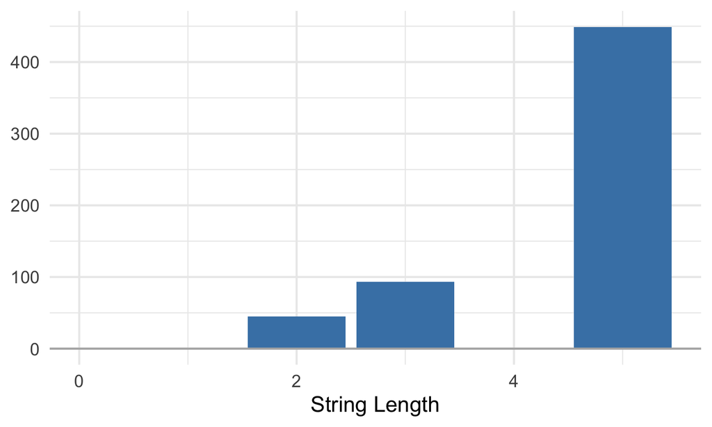

Concentration  
`numeric`

| Distinct | 127 (21.64%) |
| --- | --- |
| `NA`s | 0 |
| `Inf`/`-Inf` | 0 |

| Mean | 4.93 |
| --- | --- |
| Minimum | 0 |
| Maximum | 30 |

**Statistics**

Quantile Statistics

| Minimum | 0.00 |
| --- | --- |
| 5th Percentile | 0.14 |
| Q1 | 1.40 |
| Median | 2.90 |
| Q3 | 5.30 |
| 95th Percentile | 21.00 |
| Maximum | 30.00 |
| Range | 30.00 |
| IQR | 3.90 |

Descriptive Statistics

| Mean | 4.93 |
| --- | --- |
| Variance | 36.72 |
| Standard Deviation | 6.06 |
| Coefficient of Variation | 1.23 |

**Common Values**

| Value | Count | Frequency |
| --- | --- | --- |
| 0 | 17 | 2.9% |
| 2.9 | 16 | 2.7% |
| 1.5 | 14 | 2.4% |
| 2.7 | 14 | 2.4% |
| 2.4 | 13 | 2.2% |
| 2.8 | 13 | 2.2% |
| 0.7 | 12 | 2.0% |
| 1 | 11 | 1.9% |
| 2.3 | 11 | 1.9% |
| **Other Values** (455) | 455 | 77.5% |

**Max/Min Slices**

Maximum Values

| Value | Count | Frequency |
| --- | --- | --- |
| 0.0 | 17 | 2.90% |
| 2.9 | 16 | 2.73% |
| 1.5 | 14 | 2.39% |
| 2.7 | 14 | 2.39% |
| 2.4 | 13 | 2.21% |
| 2.8 | 13 | 2.21% |
| 0.7 | 12 | 2.04% |
| 1.0 | 11 | 1.87% |
| 2.3 | 11 | 1.87% |
| 3.6 | 11 | 1.87% |

Minimum Values

| Value | Count | Frequency |
| --- | --- | --- |
| 0.11 | 1 | 0.17% |
| 0.15 | 1 | 0.17% |
| 0.16 | 1 | 0.17% |
| 0.18 | 1 | 0.17% |
| 0.19 | 1 | 0.17% |
| 0.22 | 1 | 0.17% |
| 0.24 | 1 | 0.17% |
| 0.26 | 1 | 0.17% |
| 0.27 | 1 | 0.17% |
| 0.29 | 1 | 0.17% |

Unit  
`character`

| Distinct | 3 (0.51%) |
| --- | --- |
| `NA`s | 0 |
| `Inf`/`-Inf` | 0 |

**Common Values**

| Value | Count | Frequency |
| --- | --- | --- |
| UG/M3 | 425 | 72.4% |
| PPB | 117 | 19.9% |
| PPM | 45 | 7.7% |
| **Other Values** (0) | 0 | 0.0% |

**String Lengths**

String Lengths

| Mean | 4.4 |
| --- | --- |
| Minimum | 3.0 |
| Maximum | 5.0 |

Histogram

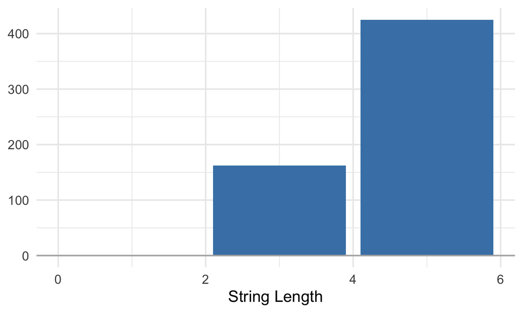

Raw_Concentration  
`numeric`

| Distinct | 225 (38.33%) |
| --- | --- |
| `NA`s | 0 |
| `Inf`/`-Inf` | 0 |

| Mean | −25.68 |
| --- | --- |
| Minimum | −999 |
| Maximum | 34.28 |

**Statistics**

Quantile Statistics

| Minimum | −999.00 |
| --- | --- |
| 5th Percentile | 0.12 |
| Q1 | 1.00 |
| Median | 3.00 |
| Q3 | 5.30 |
| 95th Percentile | 21.38 |
| Maximum | 34.28 |
| Range | 1,033.28 |
| IQR | 4.30 |

Descriptive Statistics

| Mean | −25.68 |
| --- | --- |
| Variance | 30,060.93 |
| Standard Deviation | 173.38 |
| Coefficient of Variation | −6.75 |

**Common Values**

| Value | Count | Frequency |
| --- | --- | --- |
| 4 | 32 | 5.5% |
| 5 | 29 | 4.9% |
| 3 | 28 | 4.8% |
| 2 | 24 | 4.1% |
| 1 | 20 | 3.4% |
| 6 | 20 | 3.4% |
| -999 | 18 | 3.1% |
| 1.5 | 12 | 2.0% |
| 0.7 | 11 | 1.9% |
| **Other Values** (382) | 382 | 65.1% |

**Max/Min Slices**

Maximum Values

| Value | Count | Frequency |
| --- | --- | --- |
| 4.0 | 32 | 5.45% |
| 5.0 | 29 | 4.94% |
| 3.0 | 28 | 4.77% |
| 2.0 | 24 | 4.09% |
| 1.0 | 20 | 3.41% |
| 6.0 | 20 | 3.41% |
| -999.0 | 18 | 3.07% |
| 1.5 | 12 | 2.04% |
| 0.7 | 11 | 1.87% |
| 0.8 | 11 | 1.87% |

Minimum Values

| Value | Count | Frequency |
| --- | --- | --- |
| -1.00000 | 1 | 0.17% |
| 0.10000 | 1 | 0.17% |
| 0.11835 | 1 | 0.17% |
| 0.12121 | 1 | 0.17% |
| 0.12137 | 1 | 0.17% |
| 0.12291 | 1 | 0.17% |
| 0.13169 | 1 | 0.17% |
| 0.13248 | 1 | 0.17% |
| 0.13900 | 1 | 0.17% |
| 0.14010 | 1 | 0.17% |

AQI  
`numeric`

| Distinct | 40 (6.81%) |
| --- | --- |
| `NA`s | 0 |
| `Inf`/`-Inf` | 0 |

| Mean | −64.59 |
| --- | --- |
| Minimum | −999 |
| Maximum | 40 |

**Statistics**

Quantile Statistics

| Minimum | −999.00 |
| --- | --- |
| 5th Percentile | −999.00 |
| Q1 | 5.00 |
| Median | 11.00 |
| Q3 | 18.00 |
| 95th Percentile | 25.70 |
| Maximum | 40.00 |
| Range | 1,039.00 |
| IQR | 13.00 |

Descriptive Statistics

| Mean | −64.59 |
| --- | --- |
| Variance | 72,672.22 |
| Standard Deviation | 269.58 |
| Coefficient of Variation | −4.17 |

**Common Values**

| Value | Count | Frequency |
| --- | --- | --- |
| -999 | 45 | 7.7% |
| 10 | 38 | 6.5% |
| 12 | 31 | 5.3% |
| 3 | 30 | 5.1% |
| 6 | 30 | 5.1% |
| 13 | 30 | 5.1% |
| 5 | 25 | 4.3% |
| 20 | 25 | 4.3% |
| 8 | 24 | 4.1% |
| **Other Values** (287) | 287 | 48.9% |

**Max/Min Slices**

Maximum Values

| Value | Count | Frequency |
| --- | --- | --- |
| -999 | 45 | 7.67% |
| 10 | 38 | 6.47% |
| 12 | 31 | 5.28% |
| 3 | 30 | 5.11% |
| 6 | 30 | 5.11% |
| 13 | 30 | 5.11% |
| 5 | 25 | 4.26% |
| 20 | 25 | 4.26% |
| 8 | 24 | 4.09% |
| 11 | 22 | 3.75% |

Minimum Values

| Value | Count | Frequency |
| --- | --- | --- |
| 31 | 1 | 0.17% |
| 35 | 1 | 0.17% |
| 37 | 1 | 0.17% |
| 39 | 1 | 0.17% |
| 40 | 1 | 0.17% |
| 29 | 2 | 0.34% |
| 30 | 2 | 0.34% |
| 32 | 2 | 0.34% |
| 33 | 2 | 0.34% |
| 34 | 2 | 0.34% |

Category  
`numeric`

| Distinct | 2 (0.34%) |
| --- | --- |
| `NA`s | 0 |
| `Inf`/`-Inf` | 0 |

| Mean | 0.92 |
| --- | --- |
| Minimum | 0 |
| Maximum | 1 |

**Statistics**

Quantile Statistics

| Minimum | 0.00 |
| --- | --- |
| 5th Percentile | 0.00 |
| Q1 | 1.00 |
| Median | 1.00 |
| Q3 | 1.00 |
| 95th Percentile | 1.00 |
| Maximum | 1.00 |
| Range | 1.00 |
| IQR | 0.00 |

Descriptive Statistics

| Mean | 0.92 |
| --- | --- |
| Variance | 0.07 |
| Standard Deviation | 0.27 |
| Coefficient of Variation | 0.29 |

**Common Values**

| Value | Count | Frequency |
| --- | --- | --- |
| 1 | 542 | 92.3% |
| 0 | 45 | 7.7% |
| **Other Values** (0) | 0 | 0.0% |

**Max/Min Slices**

Maximum Values

| Value | Count | Frequency |
| --- | --- | --- |
| 1 | 542 | 92.33% |
| 0 | 45 | 7.67% |

Minimum Values

| Value | Count | Frequency |
| --- | --- | --- |
| 0 | 45 | 7.67% |
| 1 | 542 | 92.33% |

Site_Name  
`character`

| Distinct | 17 (2.90%) |
| --- | --- |
| `NA`s | 0 |
| `Inf`/`-Inf` | 0 |

**Common Values**

| Value | Count | Frequency |
| --- | --- | --- |
| Seattle-Beacon Hill | 117 | 19.9% |
| Seattle-10th & Weller | 71 | 12.1% |
| Tacoma-S 36th St | 49 | 8.3% |
| Bellevue-SE 12th | 25 | 4.3% |
| Bremerton-Spruce Ave | 25 | 4.3% |
| Kent-James & Central | 25 | 4.3% |
| Lacey-College St | 25 | 4.3% |
| Lake Forest Park-Town Center | 25 | 4.3% |
| Marysville-7th Ave | 25 | 4.3% |
| **Other Values** (175) | 175 | 29.8% |

**String Lengths**

String Lengths

| Mean | 19.6 |
| --- | --- |
| Minimum | 16.0 |
| Maximum | 30.0 |

Histogram

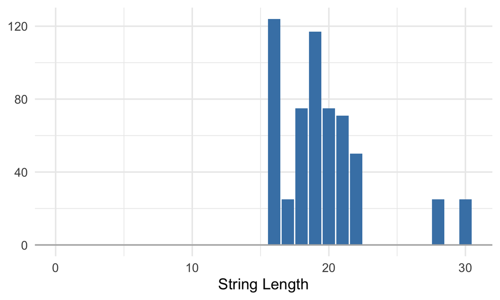

Site_Agency  
`character`

| Distinct | 1 (0.17%) |
| --- | --- |
| `NA`s | 0 |
| `Inf`/`-Inf` | 0 |

**Common Values**

| Value | Count | Frequency |
| --- | --- | --- |
| Washington Department of Ecology | 587 | 100.0% |
| **Other Values** (0) | 0 | 0.0% |

**String Lengths**

String Lengths

| Mean | 32.0 |
| --- | --- |
| Minimum | 32.0 |
| Maximum | 32.0 |

Histogram

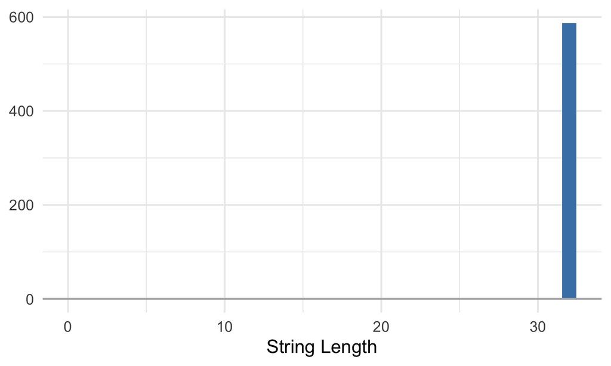

AQS_ID  
`numeric`

| Distinct | 17 (2.90%) |
| --- | --- |
| `NA`s | 0 |
| `Inf`/`-Inf` | 0 |

| Mean | 72,080,654,395.6 |
| --- | --- |
| Minimum | 530,310,003 |
| Maximum | 840,530,610,021 |

**Statistics**

Quantile Statistics

| Minimum | 530,310,003.00 |
| --- | --- |
| 5th Percentile | 530,330,017.00 |
| Q1 | 530,330,031.00 |
| Median | 530,330,080.00 |
| Q3 | 530,530,024.00 |
| 95th Percentile | 840,530,330,069.00 |
| Maximum | 840,530,610,021.00 |
| Range | 840,000,300,018.00 |
| IQR | 199,993.00 |

Descriptive Statistics

| Mean | 72,080,654,395.60 |
| --- | --- |
| Variance | 55,076,613,049,650,998,411,264.00 |
| Standard Deviation | 234,684,070,719.87 |
| Coefficient of Variation | 3.26 |

**Common Values**

| Value | Count | Frequency |
| --- | --- | --- |
| 530330080 | 117 | 19.9% |
| 530330030 | 71 | 12.1% |
| 530530024 | 49 | 8.3% |
| 530310003 | 25 | 4.3% |
| 530330017 | 25 | 4.3% |
| 530330024 | 25 | 4.3% |
| 530330031 | 25 | 4.3% |
| 530330057 | 25 | 4.3% |
| 530331011 | 25 | 4.3% |
| **Other Values** (175) | 175 | 29.8% |

**Max/Min Slices**

Maximum Values

| Value | Count | Frequency |
| --- | --- | --- |
| 530330080 | 117 | 19.93% |
| 530330030 | 71 | 12.10% |
| 530530024 | 49 | 8.35% |
| 530310003 | 25 | 4.26% |
| 530330017 | 25 | 4.26% |
| 530330024 | 25 | 4.26% |
| 530330031 | 25 | 4.26% |
| 530330057 | 25 | 4.26% |
| 530331011 | 25 | 4.26% |
| 530332004 | 25 | 4.26% |

Minimum Values

| Value | Count | Frequency |
| --- | --- | --- |
| 530310003 | 25 | 4.26% |
| 530330017 | 25 | 4.26% |
| 530330024 | 25 | 4.26% |
| 530330031 | 25 | 4.26% |
| 530330057 | 25 | 4.26% |
| 530331011 | 25 | 4.26% |
| 530332004 | 25 | 4.26% |
| 530350007 | 25 | 4.26% |
| 530450007 | 25 | 4.26% |
| 530530031 | 25 | 4.26% |

Full_AWS_ID  
`numeric`

| Distinct | 17 (2.90%) |
| --- | --- |
| `NA`s | 0 |
| `Inf`/`-Inf` | 0 |

| Mean | 72,390,785,935,485.89 |
| --- | --- |
| Minimum | 840,530,310,003 |
| Maximum | 840,840,530,610,021 |

**Statistics**

Quantile Statistics

| Minimum | 840,530,310,003.00 |
| --- | --- |
| 5th Percentile | 840,530,330,017.00 |
| Q1 | 840,530,330,031.00 |
| Median | 840,530,330,080.00 |
| Q3 | 840,530,530,024.00 |
| 95th Percentile | 840,840,530,330,069.00 |
| Maximum | 840,840,530,610,021.00 |
| Range | 840,000,000,300,018.00 |
| IQR | 199,993.00 |

Descriptive Statistics

| Mean | 72,390,785,935,485.89 |
| --- | --- |
| Variance | 55,076,602,855,701,874,402,010,333,184.00 |
| Standard Deviation | 234,684,049,001,422.06 |
| Coefficient of Variation | 3.24 |

**Common Values**

| Value | Count | Frequency |
| --- | --- | --- |
| 840530330080 | 117 | 19.9% |
| 840530330030 | 71 | 12.1% |
| 840530530024 | 49 | 8.3% |
| 840530310003 | 25 | 4.3% |
| 840530330017 | 25 | 4.3% |
| 840530330024 | 25 | 4.3% |
| 840530330031 | 25 | 4.3% |
| 840530330057 | 25 | 4.3% |
| 840530331011 | 25 | 4.3% |
| **Other Values** (175) | 175 | 29.8% |

**Max/Min Slices**

Maximum Values

| Value | Count | Frequency |
| --- | --- | --- |
| 840530330080 | 117 | 19.93% |
| 840530330030 | 71 | 12.10% |
| 840530530024 | 49 | 8.35% |
| 840530310003 | 25 | 4.26% |
| 840530330017 | 25 | 4.26% |
| 840530330024 | 25 | 4.26% |
| 840530330031 | 25 | 4.26% |
| 840530330057 | 25 | 4.26% |
| 840530331011 | 25 | 4.26% |
| 840530332004 | 25 | 4.26% |

Minimum Values

| Value | Count | Frequency |
| --- | --- | --- |
| 840530310003 | 25 | 4.26% |
| 840530330017 | 25 | 4.26% |
| 840530330024 | 25 | 4.26% |
| 840530330031 | 25 | 4.26% |
| 840530330057 | 25 | 4.26% |
| 840530331011 | 25 | 4.26% |
| 840530332004 | 25 | 4.26% |
| 840530350007 | 25 | 4.26% |
| 840530450007 | 25 | 4.26% |
| 840530530031 | 25 | 4.26% |

# Interactions

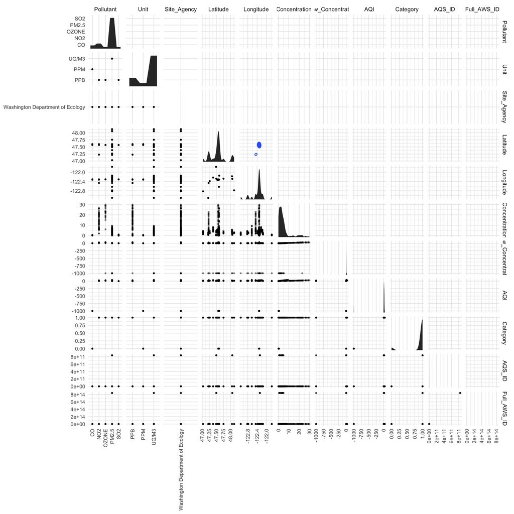

# Correlations

**Pearson**

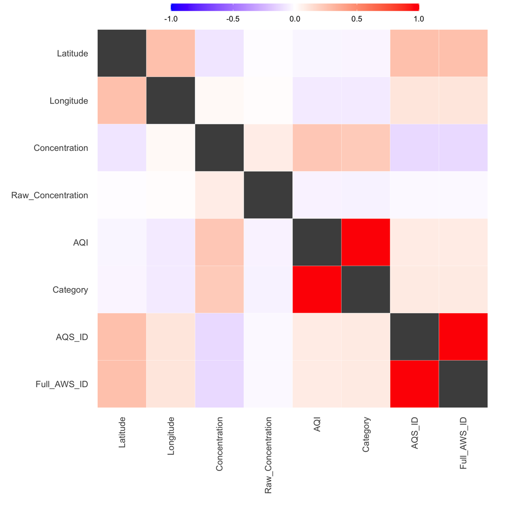

**Kendall**

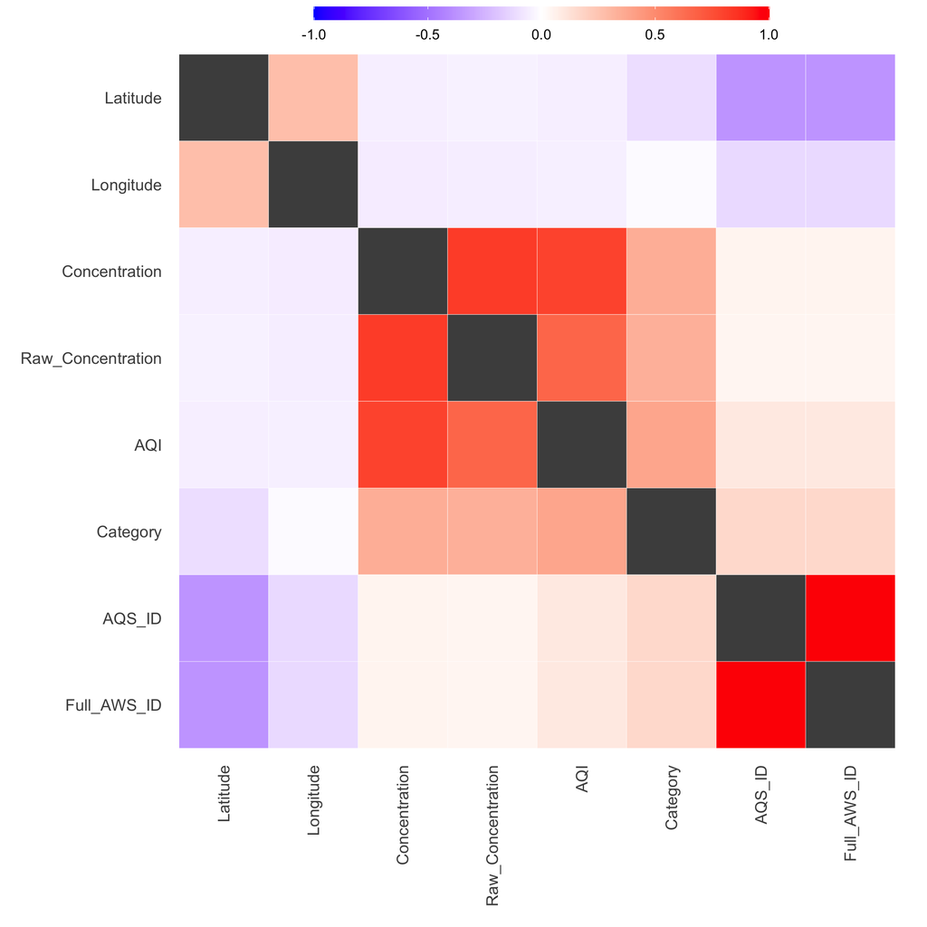

**Spearman**

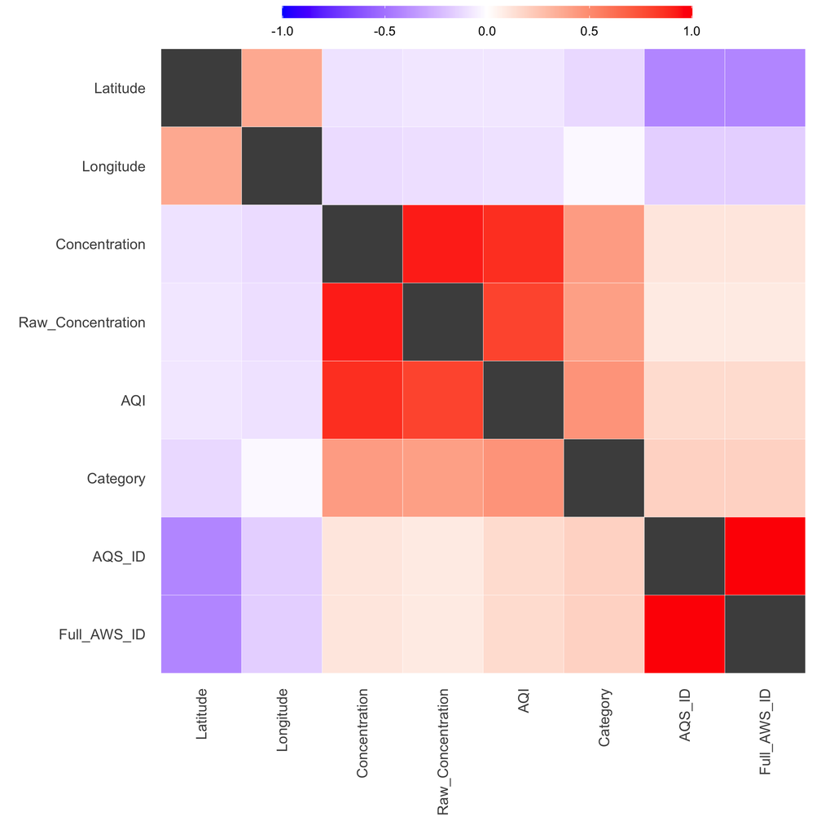

# Missing Values

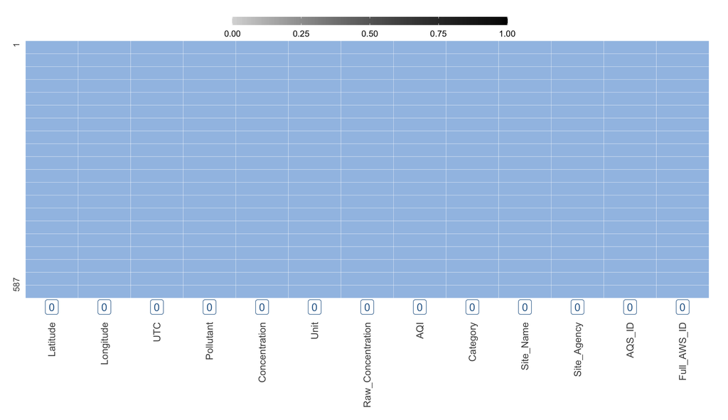

# Sample

|  | Latitude | Longitude | UTC | Pollutant | Concentration | Unit | Raw_Concentration | AQI | Category | Site_Name | Site_Agency | AQS_ID | Full_AWS_ID |
| --- | --- | --- | --- | --- | --- | --- | --- | --- | --- | --- | --- | --- | --- |
| 1 | 47.21355 | -123.1008 | 2020-12-08 22:00:00 | PM2.5 | 3.0 | UG/M3 | 3.1 | 13 | 1 | Shelton-W Franklin | Washington Department of Ecology | 530450007 | 840530450007 |
| 2 | 47.02930 | -122.8215 | 2020-12-08 22:00:00 | PM2.5 | 4.1 | UG/M3 | 4.3 | 17 | 1 | Lacey-College St | Washington Department of Ecology | 530670013 | 840530670013 |
| 3 | 48.12910 | -122.7789 | 2020-12-08 22:00:00 | PM2.5 | 2.3 | UG/M3 | 2.2 | 10 | 1 | Port Townsend-San Juan | Washington Department of Ecology | 530310003 | 840530310003 |
| 4 | 47.59267 | -122.6274 | 2020-12-08 22:00:00 | PM2.5 | 4.5 | UG/M3 | 6.0 | 19 | 1 | Bremerton-Spruce Ave | Washington Department of Ecology | 530350007 | 840530350007 |
| 5 | 47.22634 | -122.4626 | 2020-12-08 22:00:00 | PM2.5 | 8.3 | UG/M3 | 10.0 | 35 | 1 | Tacoma-S 36th St | Washington Department of Ecology | 530530024 | 840530530024 |
| 6..582 |  |  |  |  |  |  |  |  |  |  |  |  |  |
| 583 | 47.75363 | -122.2772 | 2020-12-09 22:00:00 | PM2.5 | 2.3 | UG/M3 | -999.0 | 10 | 1 | Lake Forest Park-Town Center | Washington Department of Ecology | 530330024 | 840530330024 |
| 584 | 47.38610 | -122.2302 | 2020-12-09 22:00:00 | PM2.5 | 3.7 | UG/M3 | -999.0 | 15 | 1 | Kent-James & Central | Washington Department of Ecology | 530332004 | 840530332004 |
| 585 | 48.05500 | -122.1758 | 2020-12-09 22:00:00 | PM2.5 | 4.9 | UG/M3 | -999.0 | 20 | 1 | Marysville-7th Ave | Washington Department of Ecology | 530611007 | 840530611007 |
| 586 | 47.60086 | -122.1484 | 2020-12-09 22:00:00 | PM2.5 | 1.5 | UG/M3 | -999.0 | 6 | 1 | Bellevue-SE 12th | Washington Department of Ecology | 530330031 | 840530330031 |
| 587 | 47.49020 | -121.7727 | 2020-12-09 22:00:00 | PM2.5 | 0.9 | UG/M3 | -999.0 | 4 | 1 | North Bend-North Bend Way (SO) | Washington Department of Ecology | 530330017 | 840530330017 |

## Define basic rules for data quality to ensure import assumptions are valid

Since the data is coming in without column headers, let’s establish a column schema to validate that the data conforms to what I’m expecting.

```r
# Define a column schema so we can check inputted data is as expected
schema_aqi_table <- col_schema(Latitude = "numeric",
                               Longitude = "numeric",
                               UTC = c("POSIXct"),
                               Pollutant = "character",
                               Concentration = "numeric",
                               Unit = "character",
                               Raw_Concentration = "numeric",
                               AQI = "numeric",
                               Category = "numeric",
                               Site_Name = "character",
                               Site_Agency = "character",
                               AQS_ID = "numeric",
                               Full_AWS_ID = "numeric")
```

```r
agent <- create_agent(response) %>% col_schema_match(schema_aqi_table, is_exact = FALSE) %>% interrogate()
all_passed(agent)
```

```
## [1] TRUE
```

## Does the data make sense?

We can do basic checks on the columns

```r
# define another agent with col_vals_* functions
(agent <- response %>% create_agent() %>%
  col_vals_between(vars(AQI), left = 0, right = 500) %>%
  col_vals_gte(vars(Concentration, Raw_Concentration), value = 0) %>%
  interrogate())
```

Pointblank Validation

[2020-12-09|14:31:12] tibble

|  |  | STEP | COLUMNS | VALUES | TBL | EVAL | ⋅ ⋅ ⋅ | PASS | FAIL | W | S | N | EXT |
| --- | --- | --- | --- | --- | --- | --- | --- | --- | --- | --- | --- | --- | --- |
|  | 1 | `col_vals_between()` | `▮AQI` | `[0, 500]` | → | ✓ | `587` | `542` `0.92` | `45` `0.08` | — | — | — |  |
|  | 2 | `col_vals_gte()` | `▮Concentration` | `0` | → | ✓ | `587` | `587` `1.00` | `0` `0.00` | — | — | — | — |
|  | 3 | `col_vals_gte()` | `▮Raw_Concentration` | `0` | → | ✓ | `587` | `568` `0.97` | `19` `0.03` | — | — | — |  |

2020-12-09 14:31:12 PST< 1 s2020-12-09 14:31:12 PST

If there are records that do not pass the basic checks, we can omit those records and move forward with only those that pass.

```r
clean_response <- get_sundered_data(agent, type = "pass")
fail_response <- get_sundered_data(agent, type = "fail")
```

## Define some alerts

```r
(agent_aqi <- clean_response %>% create_agent() %>%
  col_vals_lte(vars(AQI), value = 20) %>% interrogate())
```

Pointblank Validation

[2020-12-09|14:31:13] tibble

|  |  | STEP | COLUMNS | VALUES | TBL | EVAL | ⋅ ⋅ ⋅ | PASS | FAIL | W | S | N | EXT |
| --- | --- | --- | --- | --- | --- | --- | --- | --- | --- | --- | --- | --- | --- |
|  | 1 | `col_vals_lte()` | `▮AQI` | `20` | → | ✓ | `523` | `428` `0.82` | `95` `0.18` | — | — | — |  |

2020-12-09 14:31:13 PST< 1 s2020-12-09 14:31:13 PST

```r
email_create(agent_aqi)
```

## Share the results

```r
# Let's email the results if we have failed data and if we have an AQI that's at an unhealthy level
```

```r
agent <- create_agent(read_fn = ~response, label = "Air Quality Report") %>%
  col_vals_between(columns = vars(Raw_Concentration), left = 1, right = 20, preconditions = ~. %>% dplyr::filter(Pollutant == "OZONE")
                                                                                              ) %>% interrogate()
```